# Liew Ting Lok(32023723)_Chu Wey Ling(32755619)

Liew Ting Lok

2022-10-14

#### **Setting Up**

Cleaning Environment

```r
rm(list=ls())
```

Install packages and load libraries

```r
# install.package("tidyverse")
library(tidyverse)
library(ggplot2)
library(dplyr)

# install.packages("janitor")
library(janitor)

# install.packages("gt")
library(gt)

library(readr)
library(haven)

# install.packages("forcats")
library(forcats)

# install.packages("ggcorrplot")
library(ggcorrplot)

# install.packages("tidymodels")
library(tidymodels)

# install.packages("ggpubr")
library(ggpubr)

# install.packages("factoextra")
library(factoextra)
```

#### **Question 1**

**Load Dataset**

```r
customer <- read_csv("Data/customer.csv")
```

```
## ──────────────────────────────────────────────────────── Delimiter: "," dbl
## (4): ...1, has_churned, time_since_first_purchase, time_since_last_purchase
```

```r
glimpse(customer)
```

```
## Rows: 400
## Columns: 4
## $ ...1                      <dbl> 1, 2, 3, 4, 5, 6, 7, 8, 9, 10, 11, 12, 13, 1…
## $ has_churned               <dbl> 0, 0, 0, 0, 0, 0, 0, 0, 0, 0, 0, 0, 0, 0, 0,…
## $ time_since_first_purchase <dbl> -1.08922097, 1.18298297, -0.84615637, 0.0869…
## $ time_since_last_purchase  <dbl> -0.72132150, 3.63443539, -0.42758226, -0.535…
```

**i)**

```r
set.seed(55619)

is_tibble(customer)
```

```
## [1] TRUE
```

```r
# selecting only relevant variables and change certain variables from numeric to nominal
customer1 <- customer %>%
  select(-1) %>%
  mutate(across(has_churned, as.factor),
         has_churned = fct_relevel(has_churned, "1", "0"))

customer1 %>% pull(has_churned) %>% class()
```

```
## [1] "factor"
```

```r
customer1 %>% pull(has_churned) %>% levels()
```

```
## [1] "1" "0"
```

```r
# Splitting the data into training and testing data
customer1_split <- customer1 %>%
  initial_split(prop=0.7, strata = has_churned)

customer1_training <- customer1_split %>% training()
customer1_test <- customer1_split %>% testing()

# Logistic Regression Model Specification
logistic_model <- logistic_reg() %>%
  set_engine("glm") %>%
  set_mode("classification")

# Specifying feature engineering steps with recipe
customer_recipe <- recipe(has_churned~., data = customer1_training) %>%
  step_normalize(all_numeric_predictors()) %>%
  step_dummy(all_nominal_predictors())

# Initializing the workflow function and adding model specification and recipe
logistic_model_wkfl <- workflow() %>%
  add_model(logistic_model) %>%
  add_recipe(customer_recipe)

# Creating Custom Metrics
custom_metrics <- metric_set(accuracy, sens, spec, roc_auc)

# Cross-validation on the Logistic Model
customer_folds <- vfold_cv(customer1_training, v=10, strata = has_churned)

log_rs_fit <- logistic_model_wkfl %>%
  fit_resamples(resamples = customer_folds,
                metrics = custom_metrics)

log_rs_fit %>% collect_metrics()
```

```
## # A tibble: 4 × 6
##   .metric  .estimator  mean     n std_err .config
##   <chr>    <chr>      <dbl> <int>   <dbl> <chr>
## 1 accuracy binary     0.646    10  0.0326 Preprocessor1_Model1
## 2 roc_auc  binary     0.669    10  0.0403 Preprocessor1_Model1
## 3 sens     binary     0.779    10  0.0344 Preprocessor1_Model1
## 4 spec     binary     0.514    10  0.0410 Preprocessor1_Model1
```

**Interpretation of measures and Explanation**

Accuracy 64.6% of all cases were correctly predicted.

Sensitivity 77.9% of customers that have churned were predicted correctly. This figure could indicate that the model is good at predicting customers who have churned.

Specificity 51.4% of customers that have not churned were predicted correctly. This figure could imply that the model is bad at predicting customers that have not churned.

Receiver Operating Characteristic (ROC) 66.9% approximately corresponding to a C grade performance which means the model has an average performance in predicting customer churn.

Accuracy and ROC will be more preferred than Sensitivity and Specificity. As we are trying to determine the factors that influence customer churn, checking the model’s predictability on both positive and negative classes is important. This is because the model needs to be good at predicting both churning and not churning so that we can know what factors cause customers to churn and what factors influence customers to not churn.

Since Accuracy and ROC measure the model’s predictability on both positive and negative classes, these two will be relevant for evaluating the model’s performance. As for Sensitivity and Specificity, they only measure the predictability of only one between positive or negative classes, they are not preferred in this case.

**ii)**

```r
# Conduct Pre-processing for Logistic Model
customer_recipe_prep <- customer_recipe %>%
  prep(training = customer1_training)

# Apply the recipe to the training and testing dataset
customer_bake_training <- customer_recipe_prep %>%
  bake(new_data = NULL)

customer_bake_test <- customer_recipe_prep %>%
  bake(new_data = customer1_test)

# Fit the Logistic Model
logistic_fit <- logistic_model %>%
  fit(has_churned~.,
      data = customer_bake_training)

# Predicting Outcome Categories
class_predict <- logistic_fit %>%
  predict(new_data = customer_bake_test,
          type = "class")

# Estimates probabilities for each category
probs_predict <- logistic_fit %>%
  predict(new_data = customer_bake_test,
          type = "prob")

# Test the Predictive Ability of the Model
customer_results <- customer1_test %>%
  select(has_churned) %>%
  bind_cols(class_predict, probs_predict)

customer_results %>% custom_metrics(truth = has_churned,
                                    estimate = .pred_class, .pred_1)
```

```
## # A tibble: 4 × 3
##   .metric  .estimator .estimate
##   <chr>    <chr>          <dbl>
## 1 accuracy binary         0.558
## 2 sens     binary         0.55
## 3 spec     binary         0.567
## 4 roc_auc  binary         0.586
```

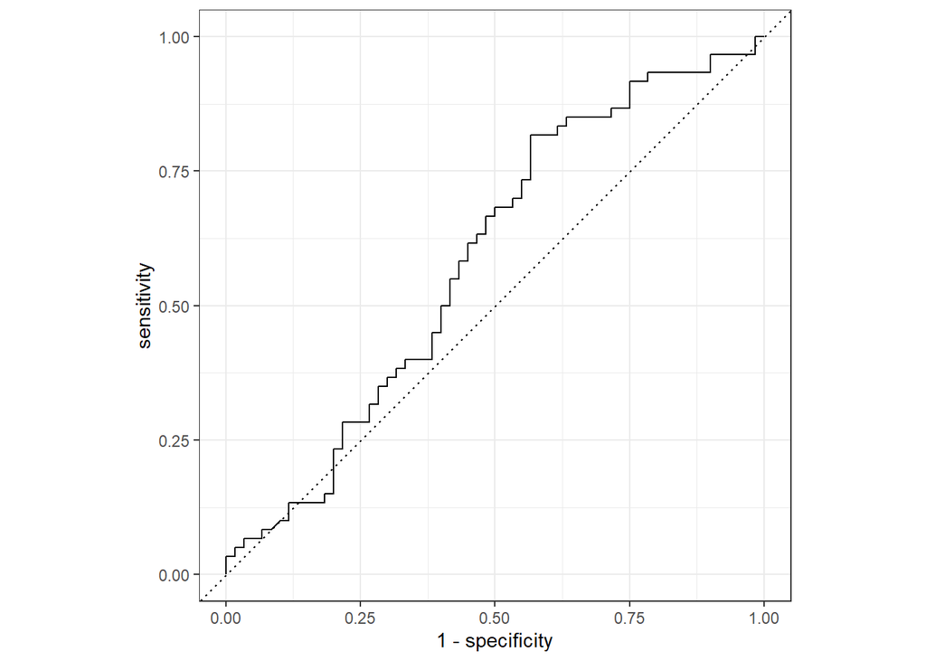

```r
# Create ROC Curve of the model
customer_results %>% roc_curve(truth = has_churned,
                                    estimate = .pred_1) %>%
  autoplot()
```

**Predictability of the Model**

All the four performance metrics are only approximately or lower than 60% which could indicate a relatively low performance of the model. In other words, we could say that the model did not predict well on the testing data and the model can be improved upon.

Furthermore, the ROC Curve also shows a poor performance of the model as the curve is considerably close to the diagonal line, which means that the model might be randomly predicting the outcomes.

**iii)**

```r
tidy(logistic_fit)
```

```
## # A tibble: 3 × 5
##   term                      estimate std.error statistic    p.value
##   <chr>                        <dbl>     <dbl>     <dbl>      <dbl>
## 1 (Intercept)                 0.0488     0.130     0.376 0.707
## 2 time_since_first_purchase   0.857      0.184     4.65  0.00000328
## 3 time_since_last_purchase   -0.745      0.167    -4.45  0.00000865
```

**Interpretation on significant variables:**

Based on the results generated, both time_since_first_purchase and time_since_last_purchase are significant as their p-values are smaller than 0.05.

#### **Question 2**

**Load Dataset**

```r
membership <- read_csv("Data/membership.csv")
glimpse(membership)
```

```
## Rows: 300
## Columns: 6
## $ age       <dbl> 47.31613, 31.38684, 43.20034, 37.31700, 40.95439, 43.03387, …
## $ gender    <chr> "Male", "Male", "Male", "Female", "Female", "Male", "Male", …
## $ income    <dbl> 49482.81, 35546.29, 44169.19, 81041.99, 79353.01, 58143.36, …
## $ kids      <dbl> 2, 1, 0, 1, 3, 4, 3, 0, 1, 0, 0, 0, 2, 3, 1, 3, 0, 0, 1, 2, …
## $ ownHome   <chr> "ownNo", "ownYes", "ownYes", "ownNo", "ownYes", "ownYes", "o…
## $ subscribe <chr> "subNo", "subNo", "subNo", "subNo", "subNo", "subNo", "subNo…
```

**i), ii), iii)**

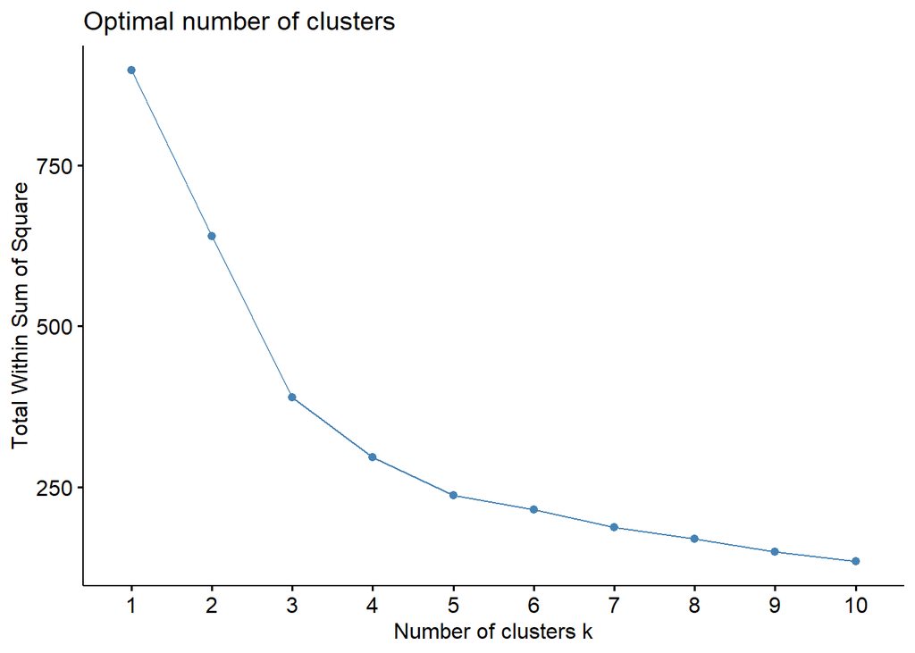

```r
# Pre-processing of Dataset
# Removing empty values
membership1 <- membership %>% na.omit() %>%
  mutate(across(c(gender, ownHome, subscribe), as_factor))

# Standardize the Variables
membership_cluster <- membership1 %>% select(age, income, kids) %>%
  scale()

# Determine the number of clusters
# using elbow method
set.seed(55619)
fviz_nbclust(membership_cluster, FUN = cluster::pam, method = "wss",
             k.max = 10)
```

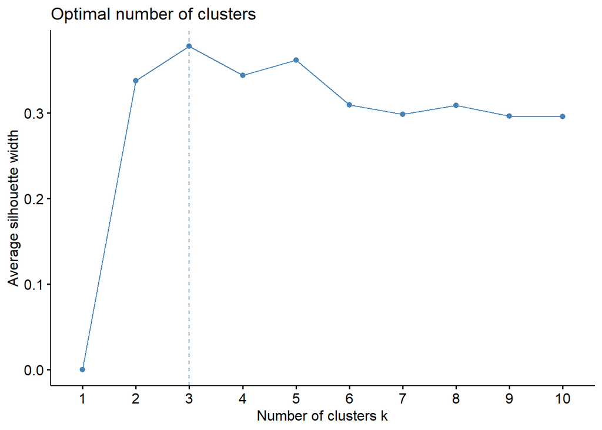

```r
# using silhouette method
set.seed(55619)
fviz_nbclust(membership_cluster, FUN = cluster::pam, method = "silhouette",
             k.max = 10)
```

**Determine the number of clusters**

Elbow method: When plotting the WCSS with the K value, the plot will appear like an Elbow. As the number of clusters increases, the WCSS value will start to decrease. WCSS value is the largest when k = 1. The graph will show a rapid change at a point and thus creating an elbow shape. From this point, the graph starts to move almost parallel to the X-axis. The K value corresponding to this point is the optimal K value or an optimal number of clusters. Based on the plot above, the elbow is created at a sharp fall of average distance at k=2, 3, and 4. With this method, it is hard to identify which k value is the best.

Silhouette method: The Silhouette method is also a method to find the optimal number of clusters and interpretation and validation of consistency within clusters of data. This method computes silhouette coefficients of each point that measure how much a point is similar to its own cluster compared to other clusters by providing a succinct graphical representation of how well each object has been classified. For each k-Means clustering model represents the silhouette coefficients in a plot and observe the fluctuations and outliers of each cluster. Based on the plot above, k=3 is said to be the best value as it has the highest average silhouette width. Silhouette method is better compared to the elbow method when finding optimal clusters because it is more obvious. Therefore, the number of clusters chosen is 3.

```r
# Perform k means cluster for 3 clusters
set.seed(55619)
membership_kmeans <- kmeans(membership_cluster, centers = 3, nstart = 20)

tidy(membership_kmeans)
```

```
## # A tibble: 3 × 6
##      age income   kids  size withinss cluster
##    <dbl>  <dbl>  <dbl> <int>    <dbl> <fct>
## 1  0.987  0.546 -0.829   108    172.  1
## 2 -0.262  0.250  0.805   124    144.  2
## 3 -1.09  -1.32  -0.150    68     71.4 3
```

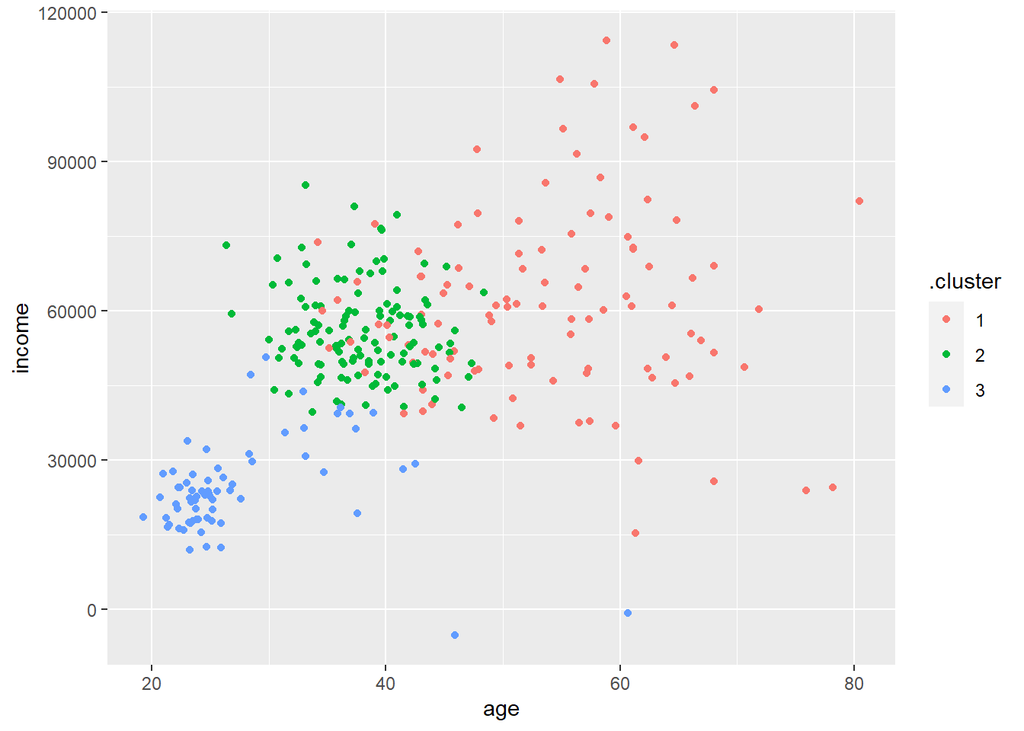

```r
augment(membership_kmeans, data = membership1) %>%
  ggplot(aes(age, income, color = .cluster)) +
  geom_point()
```

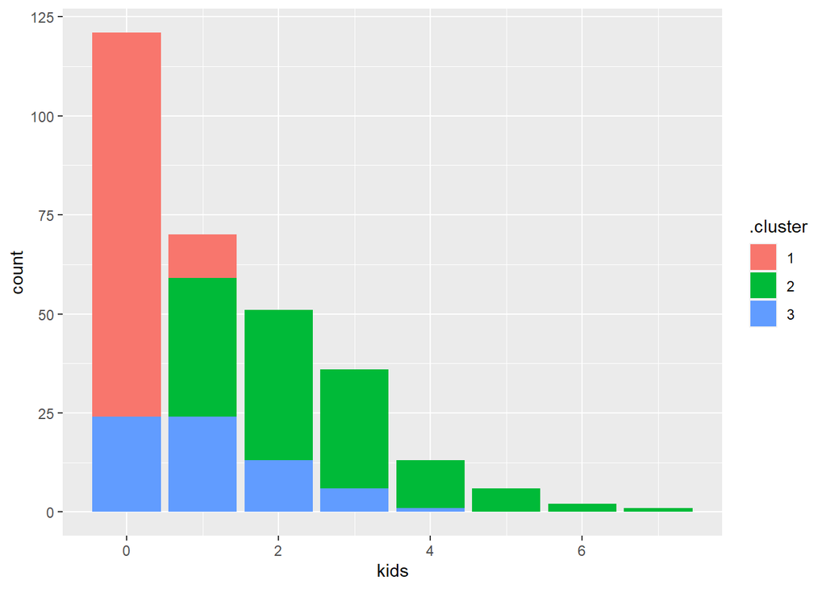

```r
augment(membership_kmeans, data = membership1) %>%
  ggplot(aes(kids, fill = .cluster)) +
  geom_bar()
```

**iv)**

**Describing the groups in terms of the variables used to group them**

Referring to the scatter plot(income and age) and bar chart(kids),

Cluster 1: Among all the three groups, this group of respondents have the highest income range of around $30,000 to $105,000 and the highest age range of around 40 to 70 years old. Additionally, the majority of them have no kids whereas the rest have only 1 kid. The highest income range can be explained by people with older age normally possessing high positions in their company and earning more income. On the other hand, the high income range can also be explained by the majority of them having no kids, where people with no kids can put extra effort in their career and earn extra income.

Cluster 2: The people in this group have a slightly lower income range and age range than Cluster 1. Their income range and age range are around $45,000 to $75,000 and 30 - 50 years old respectively. As for their kids count, it ranges from 1 to 7. In other words, everyone in this group has at least one kid. Given that everyone in this group has at least one kid, it is reasonable that they have slightly lesser income compared to Cluster 1. This is because they will need to put effort and time in educating their children and maintaining good family relationships.

Cluster 3: This group of people has the lowest income range and age range among all the groups. Majority of them have an income ranging from $15,000 to $45,000 and age ranges from 20 to 40 years old. For the kids count, the majority of them lie within the range of 0 to 3 kids. Given that this group of respondents are still considerably young working-age adults, even some of them might still be fresh-graduates, it is reasonable for them to possess the lowest income range, as they are still making advances in their career.

**v)**

```r
member_cluster <- augment(membership_kmeans, data = membership1)

# Compare the clusters on Mean Income and Mean Age
member_sat <- member_cluster %>% group_by(.cluster) %>%
  summarise(mean_income =mean(income, na.rm=TRUE),
            mean_age = mean(age, na.rm = TRUE))

member_sat %>% gt(rowname_col=",cluster") %>%
  tab_header(title="Mean Income and Mean Age",
             subtitle="by Clusters") %>%
  opt_align_table_header("center") %>%
  cols_label(mean_income="Mean Income",
             mean_age = "Mean Age")
```

Mean Income and Mean Age

by Clusters

| .cluster | Mean Income | Mean Age |
| --- | --- | --- |
| 1 | 61931.77 | 53.74454 |
| 2 | 55968.59 | 37.86893 |
| 3 | 24297.43 | 27.34909 |

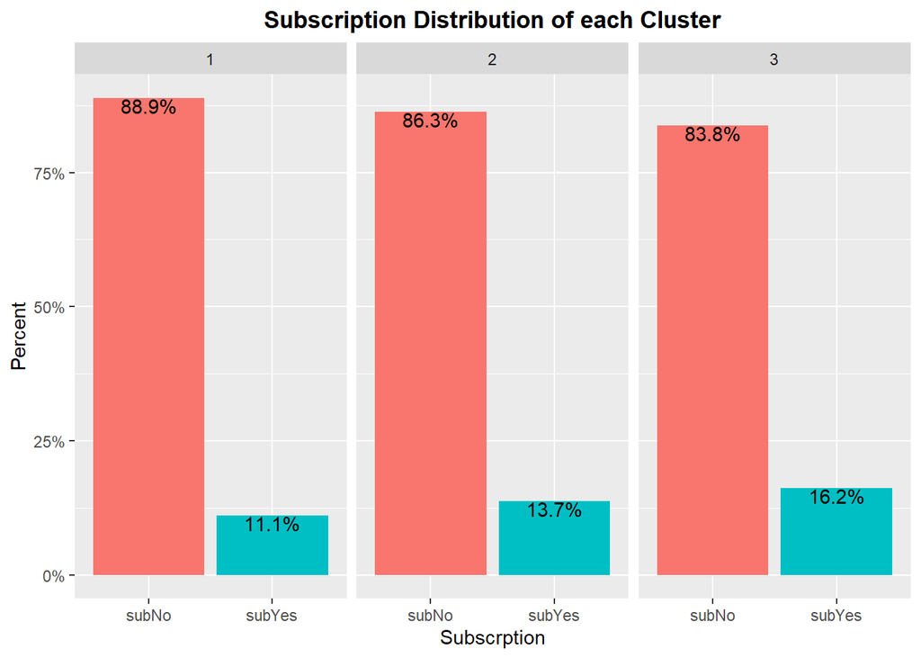

```r
# Describing the clusters on subscription
member_cluster %>%
ggplot(aes(x= subscribe,  group = .cluster)) +
    geom_bar(aes(y = ..prop.., fill = factor(..x..)), stat="count") +
    geom_text(aes( label = scales::percent(..prop..),
                   y= ..prop.. ), stat= "count", vjust = 1) +
    labs(y = "Percent", x = "Subscrption") +
    facet_grid(~.cluster) +
    scale_y_continuous(labels = scales::percent) +
    ggtitle("Subscription Distribution of each Cluster") +
    theme(legend.position = "none",
          plot.title = element_text(hjust = 0.5, face = "bold"))
```

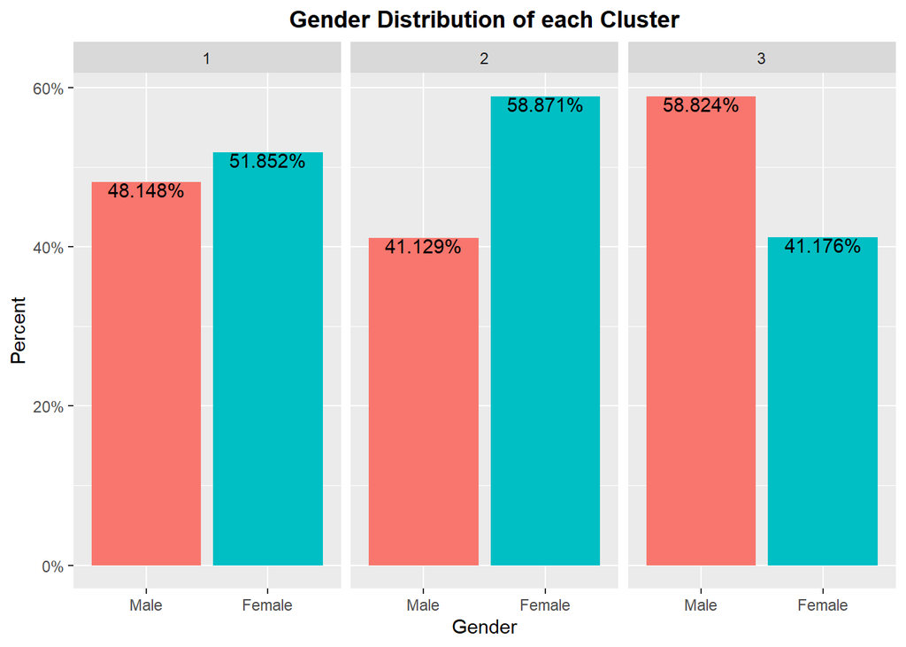

```r
# Describing the clusters on Gender
member_cluster %>%
ggplot(aes(x= gender,  group = .cluster)) +
    geom_bar(aes(y = ..prop.., fill = factor(..x..)), stat="count") +
    geom_text(aes(label = scales::percent(..prop..),
                   y= ..prop.. ), stat= "count", vjust = 1) +
    labs(y = "Percent", x = "Gender") +
    facet_grid(~.cluster) +
    scale_y_continuous(labels = scales::percent) +
    ggtitle("Gender Distribution of each Cluster") +
    theme(legend.position = "none",
          plot.title = element_text(hjust = 0.5, face = "bold"))
```

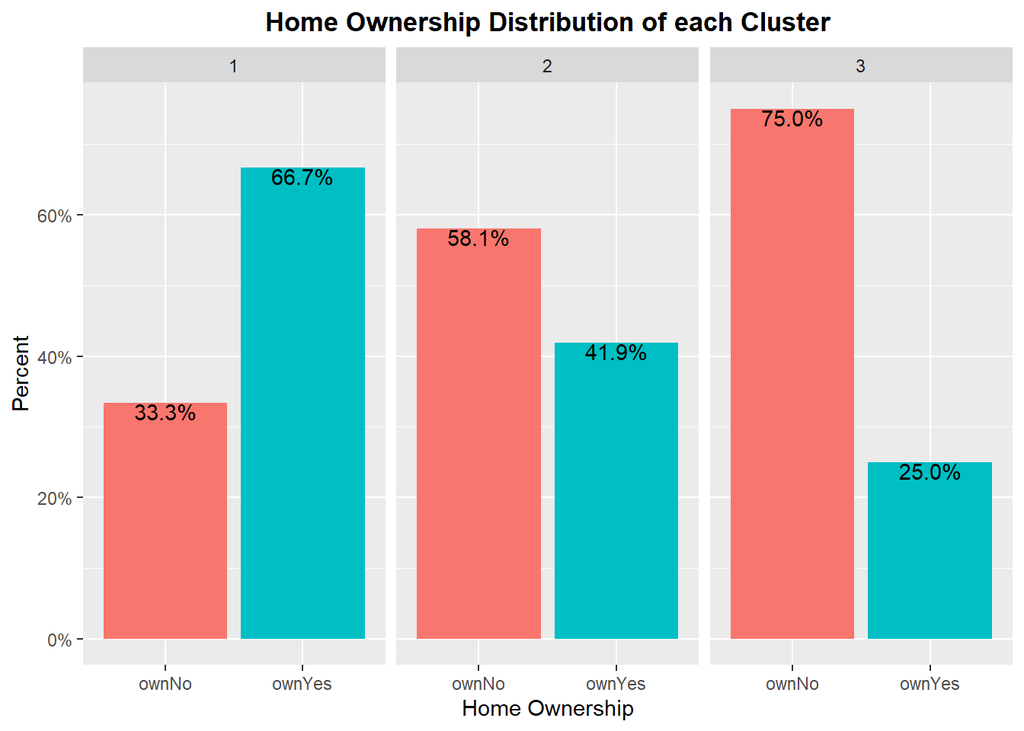

```r
# Describing the clusters on Home Ownership
member_cluster %>%
ggplot(aes(x= ownHome,  group = .cluster)) +
    geom_bar(aes(y = ..prop.., fill = factor(..x..)), stat="count") +
    geom_text(aes( label = scales::percent(..prop..),
                   y= ..prop.. ), stat= "count", vjust = 1) +
    labs(y = "Percent", x = "Home Ownership") +
    facet_grid(~.cluster) +
    scale_y_continuous(labels = scales::percent) +
    ggtitle("Home Ownership Distribution of each Cluster") +
    theme(legend.position = "none",
          plot.title = element_text(hjust = 0.5, face = "bold"))
```

**Interpretation**

For Mean Income and Mean Age, All the three clusters have the same ranking in both Mean Income and Mean Age, which is Cluster 1 > Cluster 2 > Cluster 3. This result corresponds to the findings in 2 iv).

For Subscription: By comparing the percentages, Cluster 1 (high income, high age and fewer kids) has the lowest possibility of subscribing the club membership while Cluster 3 (low income, young age and a few kids) has the highest possibility of subscribing.

For Gender Distribution: Cluster 1 has an approximate equal distribution for both male and female. Hence, we can conclude that male and female are equally possible to enter into this group where they simultaneously possess high income during high age with 0 or 1 kid. As for Cluster 2, the Female Distribution is higher than Male, implying that females are more likely to have an income range of $45,000 to $75,000 and ages between 30 - 50 years old with at least 1 child. Cluster 3 has higher the Male Distribution. This means that this group of people (low income, young age and 0-3 kids) are more likely to be Male. Since Cluster 3 has a higher Male distribution, we could conclude that Male is more likely to be interested in subscribing to the club membership.

For Home Ownership: By comparison, Cluster 1’s respondents have the highest probability of owning a home while Cluster 3 has the lowest probability of owning a home. This can be explained by their income range where people having high income are more likely to own a home. Applying this to their subscription behavior, people in Cluster 3 who are less likely to own a home increase the chances of them subscribing to the club membership.

#### **Question 3**

**Load Dataset**

```r
deli_depot <- read_sav("Data/deli depot.sav")
glimpse(deli_depot)
```

```
## Rows: 50
## Columns: 25
## $ id         <dbl> 1, 2, 3, 4, 5, 6, 7, 8, 9, 10, 11, 12, 13, 14, 15, 16, 17, …
## $ x1         <dbl> 4, 3, 6, 5, 6, 2, 3, 5, 3, 5, 3, 3, 5, 2, 4, 3, 5, 2, 4, 1,…
## $ x2         <dbl> 1, 5, 1, 2, 2, 2, 1, 1, 4, 1, 1, 4, 1, 2, 3, 3, 2, 1, 4, 2,…
## $ x3         <dbl> 7, 6, 10, 10, 9, 9, 8, 10, 6, 10, 9, 9, 9, 7, 10, 6, 9, 8, …
## $ x4         <dbl> 5, 6, 8, 7, 5, 5, 4, 7, 5, 6, 4, 7, 5, 5, 4, 5, 6, 3, 6, 5,…
## $ x5         <dbl> 2, 3, 5, 5, 3, 3, 1, 3, 3, 4, 2, 3, 3, 3, 2, 3, 2, 1, 3, 3,…
## $ x6         <dbl> 5, 8, 5, 8, 8, 6, 7, 7, 6, 7, 6, 8, 4, 7, 5, 8, 5, 6, 9, 9,…
## $ x7         <dbl+lbl> 0, 1, 0, 0, 0, 0, 1, 0, 0, 0, 0, 0, 0, 1, 0, 1, 0, 1, 1…
## $ x8         <dbl> 3, 5, 6, 5, 6, 3, 4, 5, 4, 5, 4, 6, 5, 4, 5, 4, 6, 4, 4, 3,…
## $ x9         <dbl> 4, 5, 7, 6, 5, 4, 4, 6, 4, 6, 5, 5, 5, 4, 5, 3, 6, 4, 5, 4,…
## $ x10        <dbl+lbl> 0, 1, 1, 1, 1, 0, 0, 1, 0, 1, 1, 1, 1, 0, 1, 0, 1, 0, 1…
## $ x11        <dbl+lbl> 1, 2, 3, 3, 2, 1, 1, 3, 1, 3, 1, 2, 2, 1, 2, 1, 3, 1, 2…
## $ x12        <dbl> 5, 2, 3, 3, 2, 4, 1, 3, 6, 2, 6, 3, 2, 2, 2, 1, 2, 4, 5, 1,…
## $ x13        <dbl> 4, 5, 5, 6, 5, 3, 3, 4, 3, 6, 3, 5, 5, 4, 5, 5, 6, 1, 2, 2,…
## $ x14        <dbl> 2, 3, 4, 4, 4, 5, 5, 5, 5, 4, 5, 4, 4, 3, 4, 3, 4, 2, 1, 5,…
## $ x15        <dbl> 3, 4, 6, 5, 6, 3, 4, 6, 4, 5, 4, 6, 6, 5, 6, 4, 5, 3, 3, 3,…
## $ x16        <dbl> 6, 1, 2, 1, 3, 6, 2, 2, 1, 3, 2, 2, 1, 1, 3, 2, 1, 6, 4, 4,…
## $ x17        <dbl> 1, 6, 1, 2, 1, 1, 6, 1, 2, 1, 1, 1, 3, 6, 1, 6, 3, 5, 6, 6,…
## $ x18        <dbl> 1, 1, 2, 2, 1, 1, 3, 1, 1, 2, 3, 2, 1, 1, 3, 1, 1, 3, 1, 1,…
## $ x19        <dbl> 1, 1, 2, 2, 2, 1, 1, 2, 1, 2, 2, 2, 2, 1, 2, 1, 2, 1, 1, 1,…
## $ moderate   <dbl> 0, 1, 0, 0, 1, 0, 0, 0, 0, 0, 0, 1, 1, 0, 1, 0, 0, 0, 1, 0,…
## $ far        <dbl> 0, 0, 1, 1, 0, 0, 0, 1, 0, 1, 0, 0, 0, 0, 0, 0, 1, 0, 0, 0,…
## $ distance_1 <dbl> 1, 0, 0, 0, 0, 1, 1, 0, 1, 0, 1, 0, 0, 1, 0, 1, 0, 1, 0, 1,…
## $ distance_2 <dbl> 0, 1, 0, 0, 1, 0, 0, 0, 0, 0, 0, 1, 1, 0, 1, 0, 0, 0, 1, 0,…
## $ distance_3 <dbl> 0, 0, 1, 1, 0, 0, 0, 1, 0, 1, 0, 0, 0, 0, 0, 0, 1, 0, 0, 0,…
```

**Check any missing values**

```r
sum(is.na(deli_depot))
```

```
## [1] 0
```

```r
# is.na is used to remove any variable that contains missing values as PCA should not have missing values.
```

**i)**

```r
# Mutate the labelled data to factor and remove irrelevant variables
deli_depot1 <- deli_depot %>%
  mutate(across(c(x7, x10 ,x11), as_factor)) %>%
  select(-id)

glimpse(deli_depot1)
```

```
## Rows: 50
## Columns: 24
## $ x1         <dbl> 4, 3, 6, 5, 6, 2, 3, 5, 3, 5, 3, 3, 5, 2, 4, 3, 5, 2, 4, 1,…
## $ x2         <dbl> 1, 5, 1, 2, 2, 2, 1, 1, 4, 1, 1, 4, 1, 2, 3, 3, 2, 1, 4, 2,…
## $ x3         <dbl> 7, 6, 10, 10, 9, 9, 8, 10, 6, 10, 9, 9, 9, 7, 10, 6, 9, 8, …
## $ x4         <dbl> 5, 6, 8, 7, 5, 5, 4, 7, 5, 6, 4, 7, 5, 5, 4, 5, 6, 3, 6, 5,…
## $ x5         <dbl> 2, 3, 5, 5, 3, 3, 1, 3, 3, 4, 2, 3, 3, 3, 2, 3, 2, 1, 3, 3,…
## $ x6         <dbl> 5, 8, 5, 8, 8, 6, 7, 7, 6, 7, 6, 8, 4, 7, 5, 8, 5, 6, 9, 9,…
## $ x7         <fct> FEMALE, MALE, FEMALE, FEMALE, FEMALE, FEMALE, MALE, FEMALE,…
## $ x8         <dbl> 3, 5, 6, 5, 6, 3, 4, 5, 4, 5, 4, 6, 5, 4, 5, 4, 6, 4, 4, 3,…
## $ x9         <dbl> 4, 5, 7, 6, 5, 4, 4, 6, 4, 6, 5, 5, 5, 4, 5, 3, 6, 4, 5, 4,…
## $ x10        <fct> Light User, Heavy User, Heavy User, Heavy User, Heavy User,…
## $ x11        <fct> Came from within 1 mile, Came from 1-3 miles, Came from mor…
## $ x12        <dbl> 5, 2, 3, 3, 2, 4, 1, 3, 6, 2, 6, 3, 2, 2, 2, 1, 2, 4, 5, 1,…
## $ x13        <dbl> 4, 5, 5, 6, 5, 3, 3, 4, 3, 6, 3, 5, 5, 4, 5, 5, 6, 1, 2, 2,…
## $ x14        <dbl> 2, 3, 4, 4, 4, 5, 5, 5, 5, 4, 5, 4, 4, 3, 4, 3, 4, 2, 1, 5,…
## $ x15        <dbl> 3, 4, 6, 5, 6, 3, 4, 6, 4, 5, 4, 6, 6, 5, 6, 4, 5, 3, 3, 3,…
## $ x16        <dbl> 6, 1, 2, 1, 3, 6, 2, 2, 1, 3, 2, 2, 1, 1, 3, 2, 1, 6, 4, 4,…
## $ x17        <dbl> 1, 6, 1, 2, 1, 1, 6, 1, 2, 1, 1, 1, 3, 6, 1, 6, 3, 5, 6, 6,…
## $ x18        <dbl> 1, 1, 2, 2, 1, 1, 3, 1, 1, 2, 3, 2, 1, 1, 3, 1, 1, 3, 1, 1,…
## $ x19        <dbl> 1, 1, 2, 2, 2, 1, 1, 2, 1, 2, 2, 2, 2, 1, 2, 1, 2, 1, 1, 1,…
## $ moderate   <dbl> 0, 1, 0, 0, 1, 0, 0, 0, 0, 0, 0, 1, 1, 0, 1, 0, 0, 0, 1, 0,…
## $ far        <dbl> 0, 0, 1, 1, 0, 0, 0, 1, 0, 1, 0, 0, 0, 0, 0, 0, 1, 0, 0, 0,…
## $ distance_1 <dbl> 1, 0, 0, 0, 0, 1, 1, 0, 1, 0, 1, 0, 0, 1, 0, 1, 0, 1, 0, 1,…
## $ distance_2 <dbl> 0, 1, 0, 0, 1, 0, 0, 0, 0, 0, 0, 1, 1, 0, 1, 0, 0, 0, 1, 0,…
## $ distance_3 <dbl> 0, 0, 1, 1, 0, 0, 0, 1, 0, 1, 0, 0, 0, 0, 0, 0, 1, 0, 0, 0,…
```

```r
# When importing SPSS variables, as_factor is used so the labels that were in SPSS (initially a dbl + lbl) will become the levels when the variable is changed to a factor in R so no relabelling is needed. The column “id” was removed as it is an additional variable generated when importing a dataset.

# Splitting the data into training and testing data
set.seed(55619)
deli_split <- deli_depot1 %>%
  initial_split(prop=0.75, strata = x9)

deli_train <- deli_split %>% training()
deli_test <- deli_split %>% testing()

# Specifying feature engineering steps with recipe
deli_recipe <- recipe(x9~., data = deli_train) %>%
  step_normalize(all_numeric()) %>%
  step_pca(c(x1:x6), threshold = 0.7, id="pca") %>%
  step_dummy(all_nominal_predictors())

deli_prep <- deli_recipe %>% prep()

deli_pca_bake_train <- deli_prep %>% bake(new_data = NULL)

# Obtain factor loading scores, use type = "coef"
tidy(deli_prep, id = "pca", type = "coef")
```

```
## # A tibble: 36 × 4
##    terms   value component id
##    <chr>   <dbl> <chr>     <chr>
##  1 x1    -0.199  PC1       pca
##  2 x2     0.475  PC1       pca
##  3 x3    -0.463  PC1       pca
##  4 x4     0.364  PC1       pca
##  5 x5     0.372  PC1       pca
##  6 x6     0.500  PC1       pca
##  7 x1     0.538  PC2       pca
##  8 x2    -0.0482 PC2       pca
##  9 x3     0.333  PC2       pca
## 10 x4     0.557  PC2       pca
## # … with 26 more rows
```

```r
# Obtain eigenvalues, use type = "variance"
tidy(deli_prep, id = "pca", type = "variance")
```

```
## # A tibble: 24 × 4
##    terms               value component id
##    <chr>               <dbl>     <int> <chr>
##  1 variance            2.51          1 pca
##  2 variance            1.77          2 pca
##  3 variance            0.676         3 pca
##  4 variance            0.467         4 pca
##  5 variance            0.379         5 pca
##  6 variance            0.192         6 pca
##  7 cumulative variance 2.51          1 pca
##  8 cumulative variance 4.29          2 pca
##  9 cumulative variance 4.96          3 pca
## 10 cumulative variance 5.43          4 pca
## # … with 14 more rows
```

**Justification**

When deciding how many components are sufficient to obtain eigenvalues, cumulative percentage variance is used. Based on this dataset, 2 components (PC1 and PC2) are enough as the cumulative percentage variance accounts for more than 60% of the variance, coming to a total of 71.43%.

**ii)**

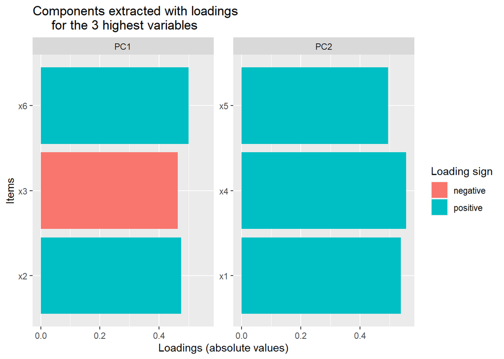

```r
# Visualization
tidy(deli_prep, id = "pca", type="coef") %>%
  filter(component%in%c("PC1","PC2")) %>%
  group_by(component) %>% slice_max(abs(value), n=3) %>%
  ungroup() %>%
  ggplot(aes(terms, abs(value), fill=value>0)) +
  geom_col()+
  coord_flip()+
  facet_wrap(~ component, scales="free_y") +
  scale_y_continuous(labels = scales::percent) %>%
labs(title="Components extracted with loadings
     for the 3 highest variables",
     fill="Loading sign",
     y="Loadings (absolute values)",
     x="Items")+
  scale_fill_discrete(labels=
      c("negative","positive"))
```

**Describing the components**

#Description for PC2

The variables of the 3 highest loadings shown in PC2 are x1 (Friendly Employees), x4 (Excellent Food Quality), and x5 (Wide variety of food). All the high loadings for PC2 are represented by variables that deal with customer’s ratings towards the restaurant. As the loading values of all the three main variables for PC2 are positive, a higher PC2 represents a higher customer rating towards the restaurant’s employee friendliness, food quality and wide variety of foods. Hence, high PC2 represents the employees are friendly, followed by the food having high quality and wide variety.

**iii)**

```r
deli_model <- linear_reg() %>%
  set_engine("lm") %>%
  set_mode("regression")

deli_fit <- deli_model %>%
fit(x9~x7_MALE+x10_Heavy.User+x11_Came.from.1.3.miles+x11_Came.from.more.than.3.miles+PC1+PC2, data=deli_pca_bake_train)

tidy(deli_fit)
```

```
## # A tibble: 7 × 5
##   term                            estimate std.error statistic      p.value
##   <chr>                              <dbl>     <dbl>     <dbl>        <dbl>
## 1 (Intercept)                      -1.22      0.164     -7.42  0.0000000355
## 2 x7_MALE                           0.612     0.215      2.85  0.00806
## 3 x10_Heavy.User                    1.30      0.314      4.13  0.000282
## 4 x11_Came.from.1.3.miles           0.0444    0.303      0.147 0.884
## 5 x11_Came.from.more.than.3.miles   0.715     0.355      2.01  0.0538
## 6 PC1                              -0.105     0.0565    -1.86  0.0729
## 7 PC2                               0.270     0.0870     3.10  0.00427
```

```r
levels(deli_depot1$x7)
```

```
## [1] "FEMALE" "MALE"
```

```r
levels(deli_depot1$x10)
```

```
## [1] "Light User" "Heavy User"
```

**Interpretation**

Among the independent variables, x7_Male, x10_Heavy.User, PC2 have a positive influence on satisfaction at 1% significance level.

For X7_MALE: The satisfaction level of male customers is significantly higher than those of female customers.

For x10_Heavy.User: The satisfaction level of customers who are heavy users are significantly higher than those of customers who are light users.